# Basic: data.frame

Jilung Hsieh

2018/7/3

```r
options(stringsAsFactors = FALSE)
```

# 1 載入台北市竊盜案資料

- 直接從網路上載入台北市竊盜案資料
- `df <- read.csv(url, fileEncoding = "big5")`這行的意思是把上面那個`url`用`read.csv()`這個函式讀取。讀取的同時，由於一般EXCEL為中文編碼`BIG5`，所以該文件八成是該台北市政單位還用EXCEL在編資料，所以要跟程式碼講說，這個網址所指到的檔案編碼為`BIG5`。
  - `fileEncoding = "big5"`稱為`read.csv()`這個函式的**參數(parameter)。
- `df`為一個自定義的變數，你愛定成什麼就定成什麼名字，唯獨不能是數字或特殊符號開頭，最好都是用英文開頭。為何命名為`df`是因為他是一個`data.frame`，思考上，他很像一個EXCEL表格。每個欄位(Column)為一個變數，每列(Row)為一筆資料。
- `<-`的記號稱為Assignment，在程式中，總是將右方的執行結果Assign給左方的變數。當我們在數學式`x = 100 + 4`時，我們做的事情也是將`100 + 4`後的結果Assign給左方的`x`。

```r
# url <- "http://data.taipei/opendata/datalist/datasetMeta/download?id=68785231-d6c5-47a1-b001-77eec70bec02&rid=34a4a431-f04d-474a-8e72-8d3f586db3df"
# df <- read.csv(url, fileEncoding = "big5")

df <- read.csv("data/tptheft.csv", fileEncoding = "big5")
str(df)
```

```
## 'data.frame':    1894 obs. of  5 variables:
##  $ 編號        : int  1 2 3 4 5 6 7 8 9 10 ...
##  $ 案類        : chr  "住宅竊盜" "住宅竊盜" "住宅竊盜" "住宅竊盜" ...
##  $ 發生.現.日期: int  780210 951016 970609 990407 991013 991024 991116 1000101 1000825 1001116 ...
##  $ 發生時段    : chr  "10~12" "19~21" "01~03" "04~06" ...
##  $ 發生.現.地點: chr  "台北市中山區新生北路3段31 ~ 60號" "台北市信義區三張里莊敬路341巷1 ~ 30號" "台北市信義區松隆里松山路615巷1 ~ 30號" "台北市萬華區雙園街61 ~ 90號" ...
```

```r
df <- read.csv("data/tptheft.csv", fileEncoding = "big5", stringsAsFactors = FALSE)
str(df)
```

```
## 'data.frame':    1894 obs. of  5 variables:
##  $ 編號        : int  1 2 3 4 5 6 7 8 9 10 ...
##  $ 案類        : chr  "住宅竊盜" "住宅竊盜" "住宅竊盜" "住宅竊盜" ...
##  $ 發生.現.日期: int  780210 951016 970609 990407 991013 991024 991116 1000101 1000825 1001116 ...
##  $ 發生時段    : chr  "10~12" "19~21" "01~03" "04~06" ...
##  $ 發生.現.地點: chr  "台北市中山區新生北路3段31 ~ 60號" "台北市信義區三張里莊敬路341巷1 ~ 30號" "台北市信義區松隆里松山路615巷1 ~ 30號" "台北市萬華區雙園街61 ~ 90號" ...
```

- **Tips**部分Mac電腦無法使用`read.csv()`從網路上取得資料又轉為`data.frame`，一個可行的辦法是先用`GET(url, write_disk("data/tptheft.csv"))`將其取回並命名為`data/tptheft.csv`，之後再用`df <- read.csv("data/tptheft.csv", fileEncoding = "big5", stringsAsFactors = FALSE)`直接讀取該檔案。

```r
library(httr)
# GET(url, write_disk("data/tptheft.csv", overwrite = TRUE))
# df <- read.csv("data/tptheft.csv", fileEncoding = "big5", stringsAsFactors = FALSE)
```

# 2 REV: 觀察資料

```r
# View(df)
head(df)    # get first part of the data.frame
```

```
##   編號     案類 發生.現.日期 發生時段
## 1    1 住宅竊盜       780210    10~12
## 2    2 住宅竊盜       951016    19~21
## 3    3 住宅竊盜       970609    01~03
## 4    4 住宅竊盜       990407    04~06
## 5    5 住宅竊盜       991013    22~24
## 6    6 住宅竊盜       991024    13~15
##                            發生.現.地點
## 1      台北市中山區新生北路3段31 ~ 60號
## 2 台北市信義區三張里莊敬路341巷1 ~ 30號
## 3 台北市信義區松隆里松山路615巷1 ~ 30號
## 4           台北市萬華區雙園街61 ~ 90號
## 5      台北市內湖區成功路4段331 ~ 360號
## 6  台北市南港區東新里興南街52巷1 ~ 30號
```

```r
class(df)
```

```
## [1] "data.frame"
```

```r
str(df)
```

```
## 'data.frame':    1894 obs. of  5 variables:
##  $ 編號        : int  1 2 3 4 5 6 7 8 9 10 ...
##  $ 案類        : chr  "住宅竊盜" "住宅竊盜" "住宅竊盜" "住宅竊盜" ...
##  $ 發生.現.日期: int  780210 951016 970609 990407 991013 991024 991116 1000101 1000825 1001116 ...
##  $ 發生時段    : chr  "10~12" "19~21" "01~03" "04~06" ...
##  $ 發生.現.地點: chr  "台北市中山區新生北路3段31 ~ 60號" "台北市信義區三張里莊敬路341巷1 ~ 30號" "台北市信義區松隆里松山路615巷1 ~ 30號" "台北市萬華區雙園街61 ~ 90號" ...
```

```r
summary(df)
```

```
##       編號            案類            發生.現.日期       發生時段
##  Min.   :   1.0   Length:1894        Min.   : 780210   Length:1894
##  1st Qu.: 474.2   Class :character   1st Qu.:1040929   Class :character
##  Median : 947.5   Mode  :character   Median :1050620   Mode  :character
##  Mean   : 947.5                      Mean   :1050234
##  3rd Qu.:1420.8                      3rd Qu.:1060321
##  Max.   :1894.0                      Max.   :1070430
##  發生.現.地點
##  Length:1894
##  Class :character
##  Mode  :character
##
##
##
```

```r
# look up help
help(summary)
?summary
```

## 2.1 資料維度

```r
dim(df)
```

```
## [1] 1894    5
```

```r
ncol(df)
```

```
## [1] 5
```

```r
nrow(df)
```

```
## [1] 1894
```

```r
length(df)
```

```
## [1] 5
```

## 2.2 觀察df中的變數

- `names(df)` 列出變數名稱
- `df$發生.現.地點` 顯示該變數內容
- `df$發生時段` 顯示該變數內容
- `length(df$發生時段)` 顯示該變數的長度（相當於有幾個）

```r
names(df)
```

```
## [1] "編號"         "案類"         "發生.現.日期" "發生時段"
## [5] "發生.現.地點"
```

```r
head(df$發生.現.地點)
```

```
## [1] "台北市中山區新生北路3段31 ~ 60號"
## [2] "台北市信義區三張里莊敬路341巷1 ~ 30號"
## [3] "台北市信義區松隆里松山路615巷1 ~ 30號"
## [4] "台北市萬華區雙園街61 ~ 90號"
## [5] "台北市內湖區成功路4段331 ~ 360號"
## [6] "台北市南港區東新里興南街52巷1 ~ 30號"
```

```r
head(df$發生時段)
```

```
## [1] "10~12" "19~21" "01~03" "04~06" "22~24" "13~15"
```

```r
length(df$發生時段)
```

```
## [1] 1894
```

# 3 整理、清理資料

- 目標：「發生時段」我打算取出前面的數字來代表時間就好，「發生地點」我打算只取出行政區名，其他地址不要。邏輯上，我要把那串字取出第x個字到第y個字，所以要用`substr()`這個函式，或者未來會教到的`stringr::str_sub()`函式。
- 用`?substr`查詢其用法和意義。相當於`getting sub string since x to y`。

```r
df$time <- substr(df$發生時段, 1, 2)
df$region <- substr(df$發生.現.地點, 4, 5)
```

# 4 計數、彙整、摘要

- 我們要回答的第一個數據問題通常是，那XXX的案例有幾個？例如大安區有多少竊盜案？買超過10000元訂單的客戶有多少人？男生和女生會修程式課的個別有多少人？這稱為計數。

## 4.1 Method 1: tapply()

```r
tapply(df$編號, df$time, length)
```

```
##  00  01  02  04  06  07  08  10  12  13  14  16  18  19  20  22
##   3 167   3 142   1 232   6 335   6 254   6 235   5 250   5 244
```

```r
tapply(df$編號, df$region, length)
```

```
## 北投 大安 大同 淡水 南港 內湖 士林 松山 萬華 文山 信義 中山 中正
##  192  164   94    1  102  185  212  134  174  132  127  235  142
```

```r
res <- tapply(df$編號, list(df$time, df$region), length)
class(res)
```

```
## [1] "matrix"
```

```r
# View(res)
```

## 4.2 Method 2: table()

```r
res <- table(df$time, df$region)

# ?table
# ?with # avoiding to type df repeatedly
# View(res)
class(res)
```

```
## [1] "table"
```

```r
res
```

```
##
##      北投 大安 大同 淡水 南港 內湖 士林 松山 萬華 文山 信義 中山 中正
##   00    0    0    0    0    1    1    0    0    0    0    0    0    1
##   01   21    8   12    0    7   11   27    8   13   11   10   27   12
##   02    0    0    0    1    1    0    0    0    1    0    0    0    0
##   04   17    9    7    0    6   20   13    5   18   10   11   17    9
##   06    0    0    0    0    1    0    0    0    0    0    0    0    0
##   07   16   22   15    0   17   25   20   18   23   17   12   30   17
##   08    0    1    0    0    0    0    0    0    1    1    2    0    1
##   10   34   41   15    0   17   31   32   39   29   24   15   31   27
##   12    1    1    0    0    0    0    1    0    0    2    1    0    0
##   13   35   26   16    0   10   31   34   15   19   15   17   23   13
##   14    0    0    0    0    3    0    1    1    0    0    1    0    0
##   16   33   23   12    0   12   22   28   14   24   16   14   19   18
##   18    1    0    0    0    2    0    1    0    0    1    0    0    0
##   19   15   15   10    0   13   23   35   22   29   14   18   36   20
##   20    3    0    0    0    0    0    0    0    1    0    0    1    0
##   22   16   18    7    0   12   21   20   12   16   21   26   51   24
```

## 4.3 Method 3: dplyr::count()

```r
res5 <- dplyr::count(df, time, region)
res6 <- tidyr::spread(res5, region, n, fill = 0)
??dplyr::count
```

# 5 Plotting

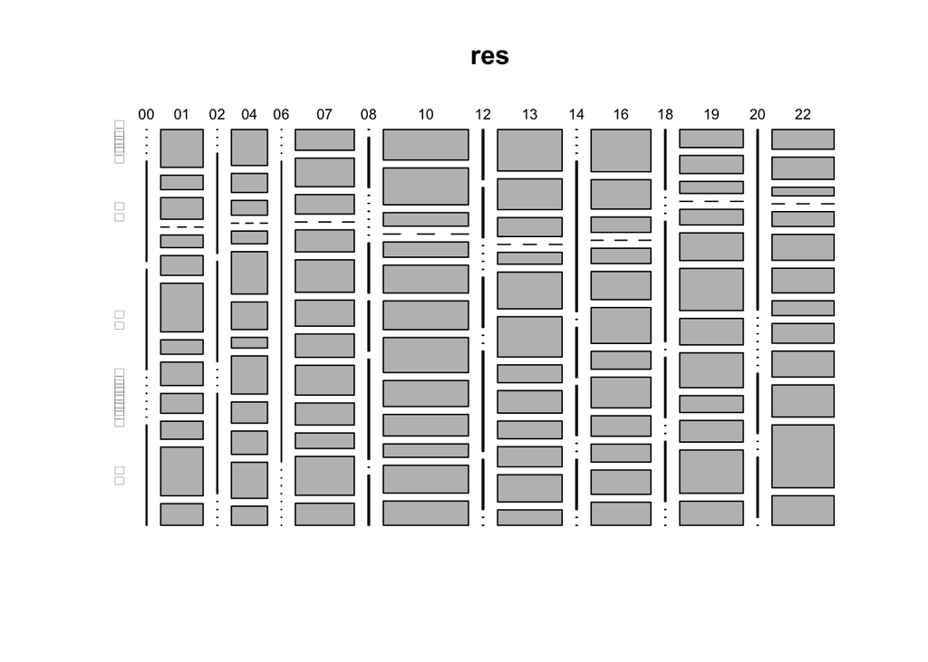

```r
mosaicplot(res)
```

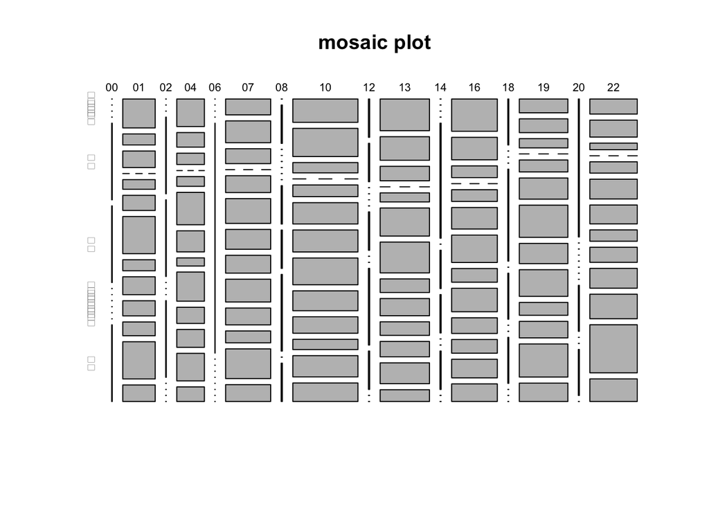

```r
mosaicplot(res, main="mosaic plot")
```

## 5.1 無法顯示中文字？

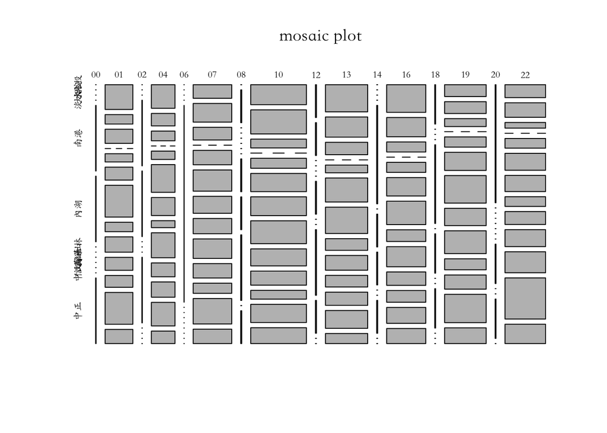

```r
par(family=('Heiti TC Light'))
par(family=('STKaiti'))
mosaicplot(res, main="mosaic plot")
```

## 5.2 想自訂顏色？

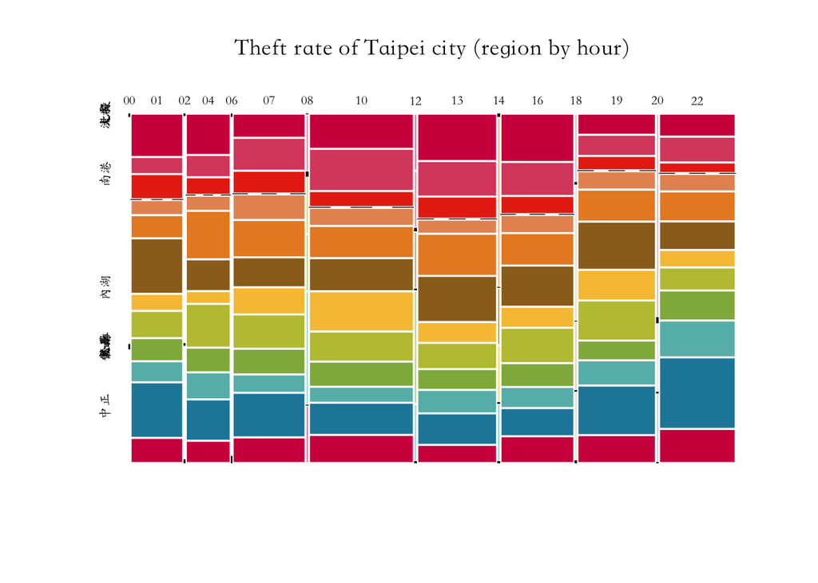

```r
# Setting the color by yourself.
colors <- c('#D0104C', '#DB4D6D', '#E83015',  '#F75C2F',
            '#E79460', '#E98B2A', '#9B6E23', '#F7C242',
            '#BEC23F', '#90B44B', '#66BAB7', '#1E88A8')
par(family=('STKaiti'))
mosaicplot(res, color=colors, border=0, off = 3,
           main="Theft rate of Taipei city (region by hour)")
```

# 6 Practice

- Check what happens if you swap the time and region in tapply()
- does it possible to extract month by substr()?
- (you may need to search how to extract the last n characters in R)

```r
x <- df$發生.現.日期
df$month <- substr(x, 3, 4) # is this correct? Try to modify it!
# res2 <- tapply(df$編號, list(df$month, df$region), length)
# res2 <- tapply(df$編號, list(df$region, df$month), length)
# mosaicplot(res2, color=colors, border=0, off = 3, main="Theft rate of Taipei city (region by hour)")
```